# pml_project

27 maggio 2016

# Prediction Assignment

## Background

Using devices such as JawboneUp, NikeFuelBand, and Fitbitit is now possible to collect a large amount of data about personal activity relatively inexpensively. These type of devices are part of the quantified self movement - a group of enthusiasts who take measurements about themselves regularly to improve their health, to find patterns in their behavior, or because they are tech geeks. One thing that people regularly do is quantify how much of a particular activity they do, but they rarely quantify how well they do it.

In this project, the goal is to use data from accelerometers on the belt, forearm, arm, and dumbell of 6 participants. They were asked to perform barbell lifts correctly and incorrectly in 5 different ways. More information is available from the website: http://groupware.les.inf.puc-rio.br/har (see the section on the Weight Lifting Exercise Dataset).

## Preparing the data and R packages

### Load packages, set caching

```r
require(caret)
```

```r
require(corrplot)
require(Rtsne)
require(xgboost)
require(stats)
require(knitr)
require(ggplot2)
require(Ckmeans.1d.dp)
knitr::opts_chunk$set(cache=TRUE)
```

For fast and accurate training the model, I choose XGBoost, an implementation of tree-based extreme gradient boosting algorithm. (As discussed in the course’s forum, this XGBoost tool is confirmed by course’s CTA to be allowed to be used in this assignment project.)

### Getting Data

```r
# URL of the training and testing data

train.url <- "https://d396qusza40orc.cloudfront.net/predmachlearn/pml-training.csv"
test.url <- "https://d396qusza40orc.cloudfront.net/predmachlearn/pml-testing.csv"
# file names
train.name <- "./data/pml-training.csv"
test.name <- "./data/pml-testing.csv"
# if directory does not exist, create new
if (!file.exists("./data")) {
  dir.create("./data")
}
# if files does not exist, download the files
if (!file.exists(train.name)) {
  download.file(train.url, destfile=train.name, method="curl")
}
if (!file.exists(test.name)) {
  download.file(test.url, destfile=test.name, method="curl")
}
# load the CSV files as data.frame
train <- read.csv("./data/pml-training.csv")
test <- read.csv("./data/pml-testing.csv")
```

The raw training data has 19622 rows of observations and 158 features (predictors). Column X is unusable row number. While the testing data has 20 observations and the same 158 features. There is one column of target outcome named classe. ###Data cleaning

First, extract target outcome (the activity quality) from training data in the data frame outcome. Print the various levels of outcome.

```r
# target outcome (label)
outcome.org <- train[, "classe"]
outcome <- outcome.org
levels(outcome)
```

```
## [1] "A" "B" "C" "D" "E"
```

Outcome has 5 levels in character format. Convert the outcome to numeric, because XGBoost gradient booster only recognizes numeric data.

```r
# convert character levels to numeric
num.class = length(levels(outcome))
levels(outcome) = 1:num.class
head(outcome)
```

```
## [1] 1 1 1 1 1 1
## Levels: 1 2 3 4 5
```

The outcome is removed from training data.

```r
# remove outcome from train
train$classe = NULL
```

The assignment rubric asks to use data from the accelerometers on the belt, forearm, arm, and dumbell, so the features are extracted based on these keywords.

```r
# filter columns on: belt, forearm, arm, dumbell
filter = grepl("belt|arm|dumbell", names(train))
train = train[, filter]
test = test[, filter]
```

Instead of less-accurate imputation of missing data, remove all columns with NA values. This might be a conservative approach and imputation methods could have been used to filling the blanks.

```r
# remove columns with NA, use test data as referal for NA
cols.without.na = colSums(is.na(test)) == 0
train = train[, cols.without.na]
test = test[, cols.without.na]
```

## Build machine learning model

Now build a machine learning model to predict activity quality (classe outcome) from the activity monitors (the features or predictors) by using XGBoost extreme gradient boosting algorithm. ###XGBoost data

XGBoost supports only numeric matrix data. Converting all training, testing and outcome data to matrix.

```r
# convert data to matrix
train.matrix = as.matrix(train)
mode(train.matrix) = "numeric"
test.matrix = as.matrix(test)
mode(test.matrix) = "numeric"
# convert outcome from factor to numeric matrix
#   xgboost takes multi-labels in [0, numOfClass)
y = as.matrix(as.integer(outcome)-1)
```

### XGBoost parameters

Set XGBoost parameters for cross validation and training. Set a multiclass classification objective as the gradient boosting’s learning function. Set evaluation metric to merror, multiclass error rate.

```r
# xgboost parameters
param <- list("objective" = "multi:softprob",    # multiclass classification
              "num_class" = num.class,    # number of classes
              "eval_metric" = "merror",    # evaluation metric
              "nthread" = 8,   # number of threads to be used
              "max_depth" = 16,    # maximum depth of tree
              "eta" = 0.3,    # step size shrinkage
              "gamma" = 0,    # minimum loss reduction
              "subsample" = 1,    # part of data instances to grow tree
              "colsample_bytree" = 1,  # subsample ratio of columns when constructing each tree
              "min_child_weight" = 12  # minimum sum of instance weight needed in a child
              )
```

### Expected error rate

Expected error rate is less than 1% for a good classification. Do cross validation to estimate the error rate using 4-fold cross validation, with 200 epochs to reach the expected error rate of less than 1%. ###4-fold cross validation

```r
# set random seed, for reproducibility
set.seed(666)
# k-fold cross validation, with timing
nround.cv = 200
system.time( bst.cv <- xgb.cv(param=param, data=train.matrix, label=y,
              nfold=4, nrounds=nround.cv, prediction=TRUE, verbose=FALSE) )
```

```
##    user  system elapsed
## 208.461   2.807 139.407
```

```r
tail(bst.cv$dt)
```

```
##    train.merror.mean train.merror.std test.merror.mean test.merror.std
## 1:                 0                0         0.005402        0.001566
## 2:                 0                0         0.005351        0.001464
## 3:                 0                0         0.005402        0.001566
## 4:                 0                0         0.005351        0.001464
## 5:                 0                0         0.005300        0.001362
## 6:                 0                0         0.005249        0.001260
```

From the cross validation, choose index with minimum multiclass error rate. Index will be used in the model training to fulfill expected minimum error rate of < 1%.

```r
# index of minimum merror
min.merror.idx = which.min(bst.cv$dt[, test.merror.mean])
min.merror.idx
```

```
## [1] 190
```

```r
# minimum merror
bst.cv$dt[min.merror.idx,]
```

```
##    train.merror.mean train.merror.std test.merror.mean test.merror.std
## 1:                 0                0         0.005198        0.001294
```

Tabulates the cross-validation’s predictions of the model against the truths.

```r
# get CV's prediction decoding
pred.cv = matrix(bst.cv$pred, nrow=length(bst.cv$pred)/num.class, ncol=num.class)
pred.cv = max.col(pred.cv, "last")
# confusion matrix
confusionMatrix(factor(y+1), factor(pred.cv))
```

```
## Confusion Matrix and Statistics
##
##           Reference
## Prediction    1    2    3    4    5
##          1 5567    8    2    3    0
##          2    8 3773   15    0    1
##          3    0   16 3390   15    1
##          4    0    0   25 3186    5
##          5    0    0    1    3 3603
##
## Overall Statistics
##
##                Accuracy : 0.9948
##                  95% CI : (0.9936, 0.9957)
##     No Information Rate : 0.2841
##     P-Value [Acc > NIR] : < 2.2e-16
##
##                   Kappa : 0.9934
##  Mcnemar's Test P-Value : NA
##
## Statistics by Class:
##
##                      Class: 1 Class: 2 Class: 3 Class: 4 Class: 5
## Sensitivity            0.9986   0.9937   0.9875   0.9935   0.9981
## Specificity            0.9991   0.9985   0.9980   0.9982   0.9998
## Pos Pred Value         0.9977   0.9937   0.9906   0.9907   0.9989
## Neg Pred Value         0.9994   0.9985   0.9973   0.9987   0.9996
## Prevalence             0.2841   0.1935   0.1750   0.1634   0.1840
## Detection Rate         0.2837   0.1923   0.1728   0.1624   0.1836
## Detection Prevalence   0.2844   0.1935   0.1744   0.1639   0.1838
## Balanced Accuracy      0.9988   0.9961   0.9927   0.9958   0.9989
```

Confusion matrix shows concentration of correct predictions is on the diagonal, as expected.

Fit the XGBoost gradient boosting model on all of the training data.

```r
# real model fit training, with full data
system.time( bst <- xgboost(param=param, data=train.matrix, label=y,
                           nrounds=min.merror.idx, verbose=0) )
```

```
##    user  system elapsed
##  64.907   0.662  41.532
```

```r
# xgboost predict test data using the trained model
pred <- predict(bst, test.matrix)
head(pred, 10)
```

```
##  [1] 2.743745e-04 9.981712e-01 1.156094e-03 1.534435e-04 2.448813e-04
##  [6] 9.991410e-01 6.096775e-04 2.325963e-04 3.937346e-06 1.278803e-05
```

### Post-processing

Output of prediction is the predicted probability of the 5 levels (columns) of outcome. Decode the quantitative 5 levels of outcomes to qualitative letters (A, B, C, D, E).

```r
# decode prediction
pred = matrix(pred, nrow=num.class, ncol=length(pred)/num.class)
pred = t(pred)
pred = max.col(pred, "last")
pred.char = toupper(letters[pred])
print(pred.char)
```

```
##  [1] "B" "A" "B" "A" "A" "E" "D" "B" "A" "A" "B" "C" "B" "A" "E" "E" "A"
## [18] "B" "B" "B"
```

### Feature importance

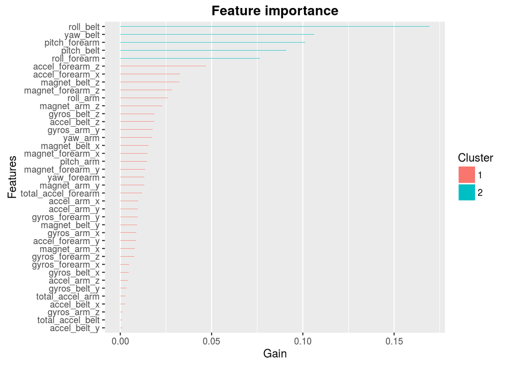

```r
# get the trained model
model = xgb.dump(bst, with.stats=TRUE)
# get the feature real names
names = dimnames(train.matrix)[[2]]
# compute feature importance matrix
importance_matrix = xgb.importance(names, model=bst)

# plot
gp = xgb.plot.importance(importance_matrix)
print(gp)
```

Feature importance plot is useful to select only best features with highest correlation to the outcome(s). To improve model fitting performance (time or overfitting), less important features can be removed.

```r
# create answer folder if it does not exist
if (!file.exists("./answer")) {
  dir.create("./answer")
}

path = "./answer"
pml_write_files = function(x) {
    n = length(x)
    for(i in 1: n) {
        filename = paste0("problem_id_", i, ".txt")
        write.table(x[i], file=file.path(path, filename),
                    quote=FALSE, row.names=FALSE, col.names=FALSE)
    }
}
pml_write_files(pred.char)
```